# Dimerization Model: Simulation & Fitting

Ren-Huai Huang

2016-02-24

## 1. Dimerization model

### 1.1. Dimerization model in equilibration

- On sensor tip:

$A + B \overset{Kd_1}{\rightleftarrows} AB \;\;$ $\Rightarrow Response (nm) = \frac{R_{max}*[A]}{Kd_1+[A]}$

- In solution :

$A + A \overset{Kd_2}{\rightleftarrows} AA$  
$Kd_2=\frac{[A]*[A]}{[AA]}=\frac{[A]^2}{[AA]}\Rightarrow [AA]=\frac{[A]^2}{Kd_2}$ & $[At] = [A] + 2[AA]$  
$\Rightarrow [At]=[A]+2*\frac{[A]^2}{Kd_2} \Rightarrow 2[A]^2 + Kd_2 * [A] -Kd_2*[At] = 0$  
$\Rightarrow [A] = \frac{-Kd_2+\sqrt{Kd_2^2+8Kd_2*[At]}}{4}$

- Combine above equations together, assumming $Kd_1 = Kd_2 = Kd$:

$Response(nm)=\frac{R_{max}*(-Kd+\sqrt[]{Kd^2+8Kd*[At]})}{3Kd+\sqrt[]{Kd^2+8Kd*[At]}}$

### 1.2. Kinetic model of dimerization

- D1D2 dimerization in solution:

$A + A \overset{Kd_2}{\rightleftarrows} AA$  
$\Rightarrow [A] = \frac{-Kd_2+\sqrt{Kd_2^2+8Kd_2*[At]}}{4}$  
Where: $[A]$ is the D1D2 monomer contration.

- On sensor tip:

$A + B \overset{k_{on}}{\underset{k_{off}}\rightleftarrows} AB \; (Kd_1)$  
$\frac{d[AB]}{dt} = k_{on} [A] [B] - k_{off} [AL]$  
$\Rightarrow$ $\frac{dy}{dt} = k_{on} [A] (R_{max} - R) - k_{off} * R$ ( Called “simple 1:1 model” )

$\Rightarrow$ $\frac{dy}{dt} = k_{on} \frac{-Kd_2+\sqrt{Kd_2^2+8Kd_2*[At]}}{4} (R_{max} - R) - k_{off} * R$  
Where $Kd_{2} = \frac{k_{off}}{k_{on}}$, assuming $Kd_1 = Kd_2$.

## 2. Simulation & plotting:

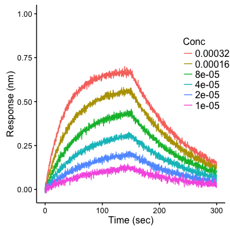

```r
# simulate the data use the following parameters
par = list(kon  = 2e2, koff = 1e-2, rmax = 1)
datsim = list()
datsim$concs <- 1e-5 * (2^(0:5));
datsim$xdata = seq(0, 300, length.out = 1501); # time
datsim$t2   = 150
datsim$ydata = NULL

# simulation
xySimulated <- dfdimer(par = par, dat = datsim, noise = 0.01)

# plot the simulation
# ySimulated$Time = time;
xy <-reshape2::melt(data = xySimulated,
                     id.vars = "Time",
                     measure.vars = rev(1:6),
                     variable.name = "Conc")

g <- ggplot()  + xlab("Time (sec)") + ylab("Response (nm)") +
    labs(linetype= 'title') +
    ylim(-0.025,1) +
    theme_classic() +
    theme(legend.position=c(0.9, 0.65),
          legend.text=element_text(size = rel(1)),
          legend.key.size=unit(0.9,"line"));
g <- g + geom_line(data = xy, aes(x = Time, y = value, color = Conc));
print(g)
```

## 3. Fitting & plotting:

```r
# init
initPar_test = list(kon =1, koff = 1, rmax = 1)
dat_test <- datsim
dat_test$t2 <- 149.9 # t2 is the beginning of the diassociation.
dat_test$lowerBound = list(kon =1e-04, koff=1e-04, rmax = 0.01);
dat_test$upperBound = list(kon =1e04, koff=1e04, rmax = 10);
dat_test$datF       = within(xySimulated, rm("Time"));

# Fit
fit <- kinfit(par = initPar_test, dat = dat_test, model = "dimer")
names(fit)
```

```
## [1] "par"      "hessian"  "fvec"     "info"     "message"  "diag"
## [7] "niter"    "rsstrace" "deviance"
```

```r
par # simulation parameters
```

```
## $kon
## [1] 200
##
## $koff
## [1] 0.01
##
## $rmax
## [1] 1
```

```r
fit$par # paramenters after fitting
```

```
## $kon
## [1] 200.8057
##
## $koff
## [1] 0.01000111
##
## $rmax
## [1] 0.996489
```

```r
cbind(simulation= par, init = initPar_test, fitting = fit$par)
```

```
##      simulation init fitting
## kon  200        1    200.8057
## koff 0.01       1    0.01000111
## rmax 1          1    0.996489
```

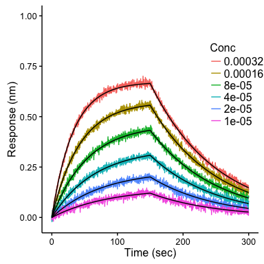

```r
#prodict and plot
predFit <- dfdimer(par = fit$par, dat = dat_test, noise = 0)
predFit <- reshape2::melt(predFit, id.vars = "Time")
g + geom_line(data=predFit, aes(x = Time, y = value, group = variable) )
```